# Exploratory Data Analysis Report

Report by dlookr package

2020-01-09

# 1 Introduction

The EDA Report provides exploratory data analysis information on objects that inherit data.frame and data.frame.

## 1.1 Information of Dataset

The dataset that generated the EDA Report is an **‘data.frame’** object. It consists of **5,607 observations** and **148 variables**.

## 1.2 Information of Variables

The variable information of the data set that generated the EDA Report is shown in the following table.:

Information of Variables

| variables | types | missing_count | missing_percent | unique_count | unique_rate |
| --- | --- | --- | --- | --- | --- |
| subject_id | integer | 0 | 0.0000000 | 5607 | 1.0000000 |
| sex | factor | 222 | 3.9593365 | 4 | 0.0007134 |
| age_years | numeric | 0 | 0.0000000 | 91 | 0.0162297 |
| bmi | numeric | 0 | 0.0000000 | 1650 | 0.2942750 |
| height_cm | numeric | 0 | 0.0000000 | 185 | 0.0329945 |
| weight_kg | numeric | 0 | 0.0000000 | 168 | 0.0299625 |
| country_of_birth | factor | 22 | 0.3923667 | 90 | 0.0160514 |
| census_region | factor | 1053 | 18.7800963 | 5 | 0.0008917 |
| economic_region | factor | 1053 | 18.7800963 | 9 | 0.0016051 |
| state | factor | 791 | 14.1073658 | 93 | 0.0165864 |
| country_residence | logical | 5607 | 100.0000000 | 1 | 0.0001783 |
| diet_type | factor | 59 | 1.0522561 | 6 | 0.0010701 |
| multivitamin | factor | 88 | 1.5694667 | 3 | 0.0005350 |
| probiotic_frequency | factor | 2990 | 53.3261994 | 6 | 0.0010701 |
| vitamin_b_supplement_frequency | factor | 3005 | 53.5937221 | 6 | 0.0010701 |
| vitamin_d_supplement_frequency | factor | 3010 | 53.6828964 | 6 | 0.0010701 |
| other_supplement_frequency | factor | 93 | 1.6586410 | 3 | 0.0005350 |
| specialized_diet_exclude_dairy | logical | 5607 | 100.0000000 | 1 | 0.0001783 |
| specialized_diet_exclude_nightshades | logical | 5607 | 100.0000000 | 1 | 0.0001783 |
| specialized_diet_exclude_refined_sugars | logical | 5607 | 100.0000000 | 1 | 0.0001783 |
| specialized_diet_fodmap | logical | 5607 | 100.0000000 | 1 | 0.0001783 |
| specialized_diet_halaal | logical | 5607 | 100.0000000 | 1 | 0.0001783 |
| specialized_diet_i_do_not_eat_a_specialized_diet | logical | 5607 | 100.0000000 | 1 | 0.0001783 |
| specialized_diet_kosher | logical | 5607 | 100.0000000 | 1 | 0.0001783 |
| specialized_diet_modified_paleo_diet | logical | 5607 | 100.0000000 | 1 | 0.0001783 |
| specialized_diet_other_restrictions_not_described_here | logical | 5607 | 100.0000000 | 1 | 0.0001783 |
| specialized_diet_paleodiet_or_primal_diet | logical | 5607 | 100.0000000 | 1 | 0.0001783 |
| specialized_diet_raw_food_diet | logical | 5607 | 100.0000000 | 1 | 0.0001783 |
| specialized_diet_unspecified | logical | 5607 | 100.0000000 | 1 | 0.0001783 |
| specialized_diet_westenprice_or_other_lowgrain_low_processed_fo | logical | 5607 | 100.0000000 | 1 | 0.0001783 |

[output cut: 118 more lines]

The target variable of the data is **‘NULL’**, and the data type of the variable is **NULL(You did not specify a target variable)**.

## 1.3 About EDA Report

EDA reports provide information and visualization results that support the EDA process. In particular, it provides a variety of information to understand the relationship between the target variable and the rest of the variables of interest.

# 2 Univariate Analysis

## 2.1 Descriptive Statistics

edaData  
148 Variables 5607 Observations

subject_id

| n | missing | distinct | Info | Mean | Gmd | .05 | .10 | .25 | .50 | .75 | .90 | .95 |
| --- | --- | --- | --- | --- | --- | --- | --- | --- | --- | --- | --- | --- |
| 5607 | 0 | 5607 | 1 | 4286 | 2233 | 1310 | 1610 | 2594 | 4359 | 5952 | 6936 | 7280 |

lowest : 1000 1001 1002 1003 1004 , highest: 7569 7570 7571 7572 7573

sex

| n | missing | distinct |
| --- | --- | --- |
| 5385 | 222 | 3 |

```
 Value      female   male  other
 Frequency    2964   2419      2
 Proportion  0.550  0.449  0.000
```

age_years

| n | missing | distinct | Info | Mean | Gmd | .05 | .10 | .25 | .50 | .75 | .90 | .95 |
| --- | --- | --- | --- | --- | --- | --- | --- | --- | --- | --- | --- | --- |
| 5607 | 0 | 91 | 1 | 46.52 | 19.81 | 10 | 23 | 35 | 48 | 60 | 67 | 71 |

lowest : 1 2 3 4 5 , highest: 88 89 92 94 101

bmi

| n | missing | distinct | Info | Mean | Gmd | .05 | .10 | .25 | .50 | .75 | .90 | .95 |
| --- | --- | --- | --- | --- | --- | --- | --- | --- | --- | --- | --- | --- |
| 5607 | 0 | 1650 | 1 | 2561 | 5033 | 16.94 | 18.75 | 20.82 | 23.31 | 26.57 | 32.83 | 46.65 |

| lowest : | 0.00 | 0.21 | 0.22 | 0.23 | 0.24 |
| --- | --- | --- | --- | --- | --- |
| highest: | 760000.00 | 830000.00 | 970000.00 | 1050000.00 | 1130000.00 |

height_cm

| n | missing | distinct | Info | Mean | Gmd | .05 | .10 | .25 | .50 | .75 | .90 | .95 |
| --- | --- | --- | --- | --- | --- | --- | --- | --- | --- | --- | --- | --- |
| 5607 | 0 | 185 | 0.998 | 168.9 | 44.2 | 81 | 147 | 162 | 170 | 178 | 184 | 188 |

lowest : 1 2 3 4 5 , highest: 1800 1820 1867 1918 16540

```
 Value          0   200   400   600   800  1000  1200  1400  1600  1800  2000 16600
 Frequency    343  5226    18     1     2     2     3     1     3     6     1     1
 Proportion 0.061 0.932 0.003 0.000 0.000 0.000 0.001 0.000 0.001 0.001 0.000 0.000
```

For the frequency table, variable is rounded to the nearest 200

weight_kg

| n | missing | distinct | Info | Mean | Gmd | .05 | .10 | .25 | .50 | .75 | .90 | .95 |
| --- | --- | --- | --- | --- | --- | --- | --- | --- | --- | --- | --- | --- |
| 5607 | 0 | 168 | 0.999 | 69.77 | 23 | 39.3 | 50.0 | 58.0 | 68.0 | 79.0 | 90.0 | 100.0 |

lowest : 2 3 4 5 6 , highest: 419 463 515 659 932

country_of_birth

| n | missing | distinct |
| --- | --- | --- |
| 5585 | 22 | 89 |

| lowest : | Algeria | Argentina | Australia | Austria | Bahrain |
| --- | --- | --- | --- | --- | --- |
| highest: | United States Minor Outlying Islands | Venezuela | Viet Nam | Zambia | Zimbabwe |

census_region

| n | missing | distinct |
| --- | --- | --- |
| 4554 | 1053 | 4 |

```
 Value        Midwest Northeast     South      West
 Frequency        595       987      1100      1872
 Proportion     0.131     0.217     0.242     0.411
```

economic_region

| n | missing | distinct |
| --- | --- | --- |
| 4554 | 1053 | 8 |

| lowest : | Far West | Great Lakes | Mideast | New England | Plains |
| --- | --- | --- | --- | --- | --- |
| highest: | New England | Plains | Rocky Mountain | Southeast | Southwest |

```
 Value            Far West    Great Lakes        Mideast    New England
 Frequency            1317            411            739            481
 Proportion          0.289          0.090          0.162          0.106

 Value              Plains Rocky Mountain      Southeast      Southwest
 Frequency             184            445            638            339
 Proportion          0.040          0.098          0.140          0.074
```

state

| n | missing | distinct |
| --- | --- | --- |
| 4816 | 791 | 92 |

lowest : AB ACT AK AL AR , highest: WI WV WY YT ZH

diet_type

| n | missing | distinct |
| --- | --- | --- |
| 5548 | 59 | 5 |

| lowest : | Omnivore | Omnivore but do not eat red meat | Vegan | Vegetarian | Vegetarian but eat seafood |
| --- | --- | --- | --- | --- | --- |
| highest: | Omnivore | Omnivore but do not eat red meat | Vegan | Vegetarian | Vegetarian but eat seafood |

Omnivore (4541, 0.818), Omnivore but do not eat red meat (385, 0.069), Vegan (127, 0.023), Vegetarian (213, 0.038), Vegetarian but eat seafood (282, 0.051)

multivitamin

| n | missing | distinct |
| --- | --- | --- |
| 5519 | 88 | 2 |

```
 Value      false  true
 Frequency   3593  1926
 Proportion 0.651 0.349
```

probiotic_frequency

| n | missing | distinct |
| --- | --- | --- |
| 2617 | 2990 | 5 |

| lowest : | Daily | Never | Occasionally (1-2 times/week) | Rarely (a few times/month) | Regularly (3-5 times/week) |
| --- | --- | --- | --- | --- | --- |
| highest: | Daily | Never | Occasionally (1-2 times/week) | Rarely (a few times/month) | Regularly (3-5 times/week) |

Daily (549, 0.210), Never (1000, 0.382), Occasionally (1-2 times/week) (267, 0.102), Rarely (a few times/month) (523, 0.200), Regularly (3-5 times/week) (278, 0.106)

vitamin_b_supplement_frequency

| n | missing | distinct |
| --- | --- | --- |
| 2602 | 3005 | 5 |

| lowest : | Daily | Never | Occasionally (1-2 times/week) | Rarely (a few times/month) | Regularly (3-5 times/week) |
| --- | --- | --- | --- | --- | --- |
| highest: | Daily | Never | Occasionally (1-2 times/week) | Rarely (a few times/month) | Regularly (3-5 times/week) |

Daily (507, 0.195), Never (1413, 0.543), Occasionally (1-2 times/week) (182, 0.070), Rarely (a few times/month) (274, 0.105), Regularly (3-5 times/week) (226, 0.087)

vitamin_d_supplement_frequency

| n | missing | distinct |
| --- | --- | --- |
| 2597 | 3010 | 5 |

| lowest : | Daily | Never | Occasionally (1-2 times/week) | Rarely (a few times/month) | Regularly (3-5 times/week) |
| --- | --- | --- | --- | --- | --- |
| highest: | Daily | Never | Occasionally (1-2 times/week) | Rarely (a few times/month) | Regularly (3-5 times/week) |

Daily (722, 0.278), Never (961, 0.370), Occasionally (1-2 times/week) (253, 0.097), Rarely (a few times/month) (319, 0.123), Regularly (3-5 times/week) (342, 0.132)

other_supplement_frequency

| n | missing | distinct |
| --- | --- | --- |
| 5514 | 93 | 2 |

```
 Value      false  true
 Frequency   2069  3445
 Proportion 0.375 0.625
```

consume_animal_products_abx

| n | missing | distinct |
| --- | --- | --- |
| 2628 | 2979 | 3 |

```
 Value            No Not sure      Yes
 Frequency       726      734     1168
 Proportion    0.276    0.279    0.444
```

drinking_water_source

| n | missing | distinct |
| --- | --- | --- |
| 5569 | 38 | 5 |

lowest : Bottled City Filtered Not sure Well , highest: Bottled City Filtered Not sure Well

```
 Value       Bottled     City Filtered Not sure     Well
 Frequency       490     2451     2088       41      499
 Proportion    0.088    0.440    0.375    0.007    0.090
```

race

| n | missing | distinct |
| --- | --- | --- |
| 5581 | 26 | 5 |

| lowest : | African American | Asian or Pacific Islander | Caucasian | Hispanic | Other |
| --- | --- | --- | --- | --- | --- |
| highest: | African American | Asian or Pacific Islander | Caucasian | Hispanic | Other |

```
 Value               African American Asian or Pacific Islander
 Frequency                         47                       208
 Proportion                     0.008                     0.037

 Value                      Caucasian                  Hispanic
 Frequency                       5081                       107
 Proportion                     0.910                     0.019

 Value                          Other
 Frequency                        138
 Proportion                     0.025
```

last_move

| n | missing | distinct |
| --- | --- | --- |
| 2639 | 2968 | 5 |

| lowest : | I have lived in my current state of residence for more than a year. | Within the past 3 months | Within the past 6 months | Within the past month | Within the past year |
| --- | --- | --- | --- | --- | --- |
| highest: | I have lived in my current state of residence for more than a year. | Within the past 3 months | Within the past 6 months | Within the past month | Within the past year |

I have lived in my current state of residence for more than a year. (2417, 0.916), Within the past 3 months (33, 0.013), Within the past 6 months (54, 0.020), Within the past month (33, 0.013), Within the past year (102, 0.039)

last_travel

| n | missing | distinct |
| --- | --- | --- |
| 5467 | 140 | 5 |

| lowest : | 1 year | 3 months | 6 months | I have not been outside of my country of residence in the past year. | Month |
| --- | --- | --- | --- | --- | --- |
| highest: | 1 year | 3 months | 6 months | I have not been outside of my country of residence in the past year. | Month |

1 year (865, 0.158), 3 months (634, 0.116), 6 months (605, 0.111), I have not been outside of my country of residence in the past year. (2916, 0.533), Month (447, 0.082)

roommates

| n | missing | distinct |
| --- | --- | --- |
| 648 | 4959 | 4 |

```
 Value      More than three             One           Three             Two
 Frequency               54             450              61              83
 Proportion           0.083           0.694           0.094           0.128
```

roommates_in_study

| n | missing | distinct |
| --- | --- | --- |
| 2370 | 3237 | 3 |

```
 Value            No Not sure      Yes
 Frequency      2052       35      283
 Proportion    0.866    0.015    0.119
```

livingwith

| n | missing | distinct |
| --- | --- | --- |
| 5518 | 89 | 3 |

```
 Value            No Not sure      Yes
 Frequency      3006      294     2218
 Proportion    0.545    0.053    0.402
```

dog

| n | missing | distinct |
| --- | --- | --- |
| 5524 | 83 | 2 |

```
 Value      false  true
 Frequency   3751  1773
 Proportion 0.679 0.321
```

cat

| n | missing | distinct |
| --- | --- | --- |
| 5479 | 128 | 2 |

```
 Value      false  true
 Frequency   3856  1623
 Proportion 0.704 0.296
```

dominant_hand

| n | missing | distinct |
| --- | --- | --- |
| 5487 | 120 | 3 |

```
 Value      I am ambidextrous  I am left handed I am right handed
 Frequency                129               505              4853
 Proportion             0.024             0.092             0.884
```

level_of_education

| n | missing | distinct |
| --- | --- | --- |
| 2547 | 3060 | 7 |

| lowest : | Associate's degree | Bachelor's degree | Did not complete high school | Graduate or Professional degree | High School or GED equilivant |
| --- | --- | --- | --- | --- | --- |
| highest: | Did not complete high school | Graduate or Professional degree | High School or GED equilivant | Some college or technical school | Some graduate school or professional |

Associate's degree (62, 0.024), Bachelor's degree (634, 0.249), Did not complete high school (100, 0.039), Graduate or Professional degree (1218, 0.478), High School or GED equilivant (111, 0.044), Some college or technical school (216, 0.085), Some graduate school or professional (206, 0.081)

exercise_frequency

| n | missing | distinct |
| --- | --- | --- |
| 5559 | 48 | 5 |

| lowest : | Daily | Never | Occasionally (1-2 times/week) | Rarely (a few times/month) | Regularly (3-5 times/week) |
| --- | --- | --- | --- | --- | --- |
| highest: | Daily | Never | Occasionally (1-2 times/week) | Rarely (a few times/month) | Regularly (3-5 times/week) |

Daily (1281, 0.230), Never (151, 0.027), Occasionally (1-2 times/week) (1260, 0.227), Rarely (a few times/month) (597, 0.107), Regularly (3-5 times/week) (2270, 0.408)

exercise_location

| n | missing | distinct |
| --- | --- | --- |
| 5416 | 191 | 5 |

| lowest : | Both | Depends on the season | Indoors | None of the above | Outdoors |
| --- | --- | --- | --- | --- | --- |
| highest: | Both | Depends on the season | Indoors | None of the above | Outdoors |

```
 Value                       Both Depends on the season               Indoors
 Frequency                   1926                   633                  1184
 Proportion                 0.356                 0.117                 0.219

 Value          None of the above              Outdoors
 Frequency                    161                  1512
 Proportion                 0.030                 0.279
```

nail_biter

| n | missing | distinct |
| --- | --- | --- |
| 5449 | 158 | 2 |

```
 Value      false  true
 Frequency   4380  1069
 Proportion 0.804 0.196
```

pool_frequency

| n | missing | distinct |
| --- | --- | --- |
| 5557 | 50 | 5 |

| lowest : | Daily | Never | Occasionally (1-2 times/week) | Rarely (a few times/month) | Regularly (3-5 times/week) |
| --- | --- | --- | --- | --- | --- |
| highest: | Daily | Never | Occasionally (1-2 times/week) | Rarely (a few times/month) | Regularly (3-5 times/week) |

Daily (33, 0.006), Never (2672, 0.481), Occasionally (1-2 times/week) (460, 0.083), Rarely (a few times/month) (2211, 0.398), Regularly (3-5 times/week) (181, 0.033)

smoking_frequency

| n | missing | distinct |
| --- | --- | --- |
| 5561 | 46 | 5 |

| lowest : | Daily | Never | Occasionally (1-2 times/week) | Rarely (a few times/month) | Regularly (3-5 times/week) |
| --- | --- | --- | --- | --- | --- |
| highest: | Daily | Never | Occasionally (1-2 times/week) | Rarely (a few times/month) | Regularly (3-5 times/week) |

Daily (59, 0.011), Never (5283, 0.950), Occasionally (1-2 times/week) (35, 0.006), Rarely (a few times/month) (159, 0.029), Regularly (3-5 times/week) (25, 0.004)

alcohol_consumption

| n | missing | distinct |
| --- | --- | --- |
| 5558 | 49 | 2 |

```
 Value      false  true
 Frequency   1345  4213
 Proportion 0.242 0.758
```

alcohol_frequency

| n | missing | distinct |
| --- | --- | --- |
| 5558 | 49 | 5 |

| lowest : | Daily | Never | Occasionally (1-2 times/week) | Rarely (a few times/month) | Regularly (3-5 times/week) |
| --- | --- | --- | --- | --- | --- |
| highest: | Daily | Never | Occasionally (1-2 times/week) | Rarely (a few times/month) | Regularly (3-5 times/week) |

Daily (631, 0.114), Never (1345, 0.242), Occasionally (1-2 times/week) (1177, 0.212), Rarely (a few times/month) (1350, 0.243), Regularly (3-5 times/week) (1055, 0.190)

alcohol_types_beercider

| n | missing | distinct |
| --- | --- | --- |
| 5607 | 0 | 4 |

```
 Value      false    No  true   Yes
 Frequency   4501     7  1097     2
 Proportion 0.803 0.001 0.196 0.000
```

alcohol_types_red_wine

| n | missing | distinct |
| --- | --- | --- |
| 5607 | 0 | 2 |

```
 Value      false  true
 Frequency   4144  1463
 Proportion 0.739 0.261
```

alcohol_types_sour_beers

| n | missing | distinct |
| --- | --- | --- |
| 5607 | 0 | 2 |

```
 Value      false  true
 Frequency   5509    98
 Proportion 0.983 0.017
```

alcohol_types_spiritshard_alcohol

| n | missing | distinct |
| --- | --- | --- |
| 5607 | 0 | 2 |

```
 Value      false  true
 Frequency   4742   865
 Proportion 0.846 0.154
```

alcohol_types_unspecified

| n | missing | distinct |
| --- | --- | --- |
| 5607 | 0 | 2 |

```
 Value      false  true
 Frequency   2026  3581
 Proportion 0.361 0.639
```

alcohol_types_white_wine

| n | missing | distinct |
| --- | --- | --- |
| 5607 | 0 | 2 |

```
 Value      false  true
 Frequency   4567  1040
 Proportion 0.815 0.185
```

teethbrushing_frequency

| n | missing | distinct |
| --- | --- | --- |
| 5549 | 58 | 5 |

| lowest : | Daily | Never | Occasionally (1-2 times/week) | Rarely (a few times/month) | Regularly (3-5 times/week) |
| --- | --- | --- | --- | --- | --- |
| highest: | Daily | Never | Occasionally (1-2 times/week) | Rarely (a few times/month) | Regularly (3-5 times/week) |

Daily (5275, 0.951), Never (20, 0.004), Occasionally (1-2 times/week) (41, 0.007), Rarely (a few times/month) (20, 0.004), Regularly (3-5 times/week) (193, 0.035)

flossing_frequency

| n | missing | distinct |
| --- | --- | --- |
| 5567 | 40 | 5 |

| lowest : | Daily | Never | Occasionally (1-2 times/week) | Rarely (a few times/month) | Regularly (3-5 times/week) |
| --- | --- | --- | --- | --- | --- |
| highest: | Daily | Never | Occasionally (1-2 times/week) | Rarely (a few times/month) | Regularly (3-5 times/week) |

Daily (2295, 0.412), Never (537, 0.096), Occasionally (1-2 times/week) (875, 0.157), Rarely (a few times/month) (898, 0.161), Regularly (3-5 times/week) (962, 0.173)

cosmetics_frequency

| n | missing | distinct |
| --- | --- | --- |
| 5552 | 55 | 5 |

| lowest : | Daily | Never | Occasionally (1-2 times/week) | Rarely (a few times/month) | Regularly (3-5 times/week) |
| --- | --- | --- | --- | --- | --- |
| highest: | Daily | Never | Occasionally (1-2 times/week) | Rarely (a few times/month) | Regularly (3-5 times/week) |

Daily (1056, 0.190), Never (3104, 0.559), Occasionally (1-2 times/week) (328, 0.059), Rarely (a few times/month) (528, 0.095), Regularly (3-5 times/week) (536, 0.097)

deodorant_use

| n | missing | distinct |
| --- | --- | --- |
| 5551 | 56 | 4 |

I do not use deodorant or an antiperspirant (1659, 0.299), I use an antiperspirant (1189, 0.214), I use deodorant (2036, 0.367), Not sure, but I use some form of deodorant/antiperspirant (667, 0.120)

sleep_duration

| n | missing | distinct |
| --- | --- | --- |
| 5573 | 34 | 5 |

| lowest : | 5-6 hours | 6-7 hours | 7-8 hours | 8 or more hours | Less than 5 hours |
| --- | --- | --- | --- | --- | --- |
| highest: | 5-6 hours | 6-7 hours | 7-8 hours | 8 or more hours | Less than 5 hours |

```
 Value              5-6 hours         6-7 hours         7-8 hours   8 or more hours
 Frequency                497              1654              2328              1018
 Proportion             0.089             0.297             0.418             0.183

 Value      Less than 5 hours
 Frequency                 76
 Proportion             0.014
```

softener

| n | missing | distinct |
| --- | --- | --- |
| 5450 | 157 | 4 |

```
 Value      false    No  true   Yes
 Frequency   3681     5  1761     3
 Proportion 0.675 0.001 0.323 0.001
```

bowel_movement_frequency

| n | missing | distinct |
| --- | --- | --- |
| 2586 | 3021 | 6 |

| lowest : | Five or more | Four | Less than one | One | Three |
| --- | --- | --- | --- | --- | --- |
| highest: | Four | Less than one | One | Three | Two |

```
 Value       Five or more          Four Less than one           One         Three
 Frequency             43            68           283          1278           211
 Proportion         0.017         0.026         0.109         0.494         0.082

 Value                Two
 Frequency            703
 Proportion         0.272
```

bowel_movement_quality

| n | missing | distinct |
| --- | --- | --- |
| 2574 | 3033 | 7 |

| lowest : | I don't know, I do not have a point of reference | I tend to be constipated (have difficulty passing stool) | I tend to be constipated (have difficulty passing stool) - Type 1 and 2 | I tend to have diarrhea (watery stool) | I tend to have diarrhea (watery stool) - Type 5, 6 and 7 |
| --- | --- | --- | --- | --- | --- |
| highest: | I tend to be constipated (have difficulty passing stool) - Type 1 and 2 | I tend to have diarrhea (watery stool) | I tend to have diarrhea (watery stool) - Type 5, 6 and 7 | I tend to have normal formed stool | I tend to have normal formed stool - Type 3 and 4 |

antibiotic_history

| n | missing | distinct |
| --- | --- | --- |
| 5536 | 71 | 5 |

| lowest : | 6 months | I have not taken antibiotics in the past year. | Month | Week | Year |
| --- | --- | --- | --- | --- | --- |
| highest: | 6 months | I have not taken antibiotics in the past year. | Month | Week | Year |

6 months (719, 0.130), I have not taken antibiotics in the past year. (3752, 0.678), Month (165, 0.030), Week (113, 0.020), Year (787, 0.142)

flu_vaccine_date

| n | missing | distinct |
| --- | --- | --- |
| 5506 | 101 | 5 |

| lowest : | 6 months | I have not gotten the flu vaccine in the past year. | Month | Week | Year |
| --- | --- | --- | --- | --- | --- |
| highest: | 6 months | I have not gotten the flu vaccine in the past year. | Month | Week | Year |

6 months (1104, 0.201), I have not gotten the flu vaccine in the past year. (3076, 0.559), Month (152, 0.028), Week (26, 0.005), Year (1148, 0.208)

contraceptive

| n | missing | distinct |
| --- | --- | --- |
| 3969 | 1638 | 6 |

| lowest : | No | Yes, I am taking the pill | Yes, I use a contraceptive patch (Ortho-Evra) | Yes, I use a hormonal IUD (Mirena) | Yes, I use an injected contraceptive (DMPA) |
| --- | --- | --- | --- | --- | --- |
| highest: | Yes, I am taking the pill | Yes, I use a contraceptive patch (Ortho-Evra) | Yes, I use a hormonal IUD (Mirena) | Yes, I use an injected contraceptive (DMPA) | Yes, I use the NuvaRing |

No (3687, 0.929), Yes, I am taking the pill (188, 0.047), Yes, I use a contraceptive patch (Ortho-Evra) (6, 0.002), Yes, I use a hormonal IUD (Mirena) (53, 0.013), Yes, I use an injected contraceptive (DMPA) (9, 0.002), Yes, I use the NuvaRing (26, 0.007)

pregnant

| n | missing | distinct |
| --- | --- | --- |
| 3448 | 2159 | 3 |

```
 Value         false Not sure     true
 Frequency      3406       12       30
 Proportion    0.988    0.003    0.009
```

weight_change

| n | missing | distinct |
| --- | --- | --- |
| 5516 | 91 | 3 |

```
 Value      Decreased more than 10 pounds Increased more than 10 pounds
 Frequency                            524                           398
 Proportion                         0.095                         0.072

 Value                    Remained stable
 Frequency                           4594
 Proportion                         0.833
```

tonsils_removed

| n | missing | distinct |
| --- | --- | --- |
| 5481 | 126 | 3 |

```
 Value         false Not sure     true
 Frequency      4007       26     1448
 Proportion    0.731    0.005    0.264
```

appendix_removed

| n | missing | distinct |
| --- | --- | --- |
| 5493 | 114 | 3 |

```
 Value         false Not sure     true
 Frequency      4934       14      545
 Proportion    0.898    0.003    0.099
```

chickenpox

| n | missing | distinct |
| --- | --- | --- |
| 5514 | 93 | 3 |

```
 Value            No Not sure      Yes
 Frequency       812      149     4553
 Proportion    0.147    0.027    0.826
```

acne_medication

| n | missing | distinct |
| --- | --- | --- |
| 5494 | 113 | 2 |

```
 Value      false  true
 Frequency   5362   132
 Proportion 0.976 0.024
```

acne_medication_otc

| n | missing | distinct |
| --- | --- | --- |
| 5516 | 91 | 2 |

```
 Value      false  true
 Frequency   5080   436
 Proportion 0.921 0.079
```

csection

| n | missing | distinct |
| --- | --- | --- |
| 5529 | 78 | 3 |

```
 Value         false Not sure     true
 Frequency      4775      206      548
 Proportion    0.864    0.037    0.099
```

fed_as_infant

| n | missing | distinct |
| --- | --- | --- |
| 2621 | 2986 | 4 |

```
 Value      A mixture of breast milk and formula                             Not sure
 Frequency                                   436                                  357
 Proportion                                0.166                                0.136

 Value                     Primarily breast milk             Primarily infant formula
 Frequency                                  1077                                  751
 Proportion                                0.411                                0.287
```

add_adhd

| n | missing | distinct |
| --- | --- | --- |
| 2599 | 3008 | 4 |

Diagnosed by a medical professional (doctor, physician assistant) (121, 0.047), Diagnosed by an alternative medicine practitioner (8, 0.003), I do not have this condition (2377, 0.915), Self-diagnosed (93, 0.036)

alzheimers

| n | missing | distinct |
| --- | --- | --- |
| 2638 | 2969 | 3 |

Diagnosed by a medical professional (doctor, physician assistant) (2, 0.001), I do not have this condition (2635, 0.999), Self-diagnosed (1, 0.000)

lung_disease

| n | missing | distinct |
| --- | --- | --- |
| 5220 | 387 | 4 |

Diagnosed by a medical professional (doctor, physician assistant) (329, 0.063), Diagnosed by an alternative medicine practitioner (3, 0.001), I do not have this condition (4876, 0.934), Self-diagnosed (12, 0.002)

asd

| n | missing | distinct |
| --- | --- | --- |
| 2623 | 2984 | 4 |

Diagnosed by a medical professional (doctor, physician assistant) (73, 0.028), Diagnosed by an alternative medicine practitioner (2, 0.001), I do not have this condition (2524, 0.962), Self-diagnosed (24, 0.009)

autoimmune

| n | missing | distinct |
| --- | --- | --- |
| 2597 | 3010 | 4 |

Diagnosed by a medical professional (doctor, physician assistant) (295, 0.114), Diagnosed by an alternative medicine practitioner (18, 0.007), I do not have this condition (2265, 0.872), Self-diagnosed (19, 0.007)

fungal_overgrowth

| n | missing | distinct |
| --- | --- | --- |
| 2555 | 3052 | 4 |

Diagnosed by a medical professional (doctor, physician assistant) (122, 0.048), Diagnosed by an alternative medicine practitioner (186, 0.073), I do not have this condition (2118, 0.829), Self-diagnosed (129, 0.050)

cdiff

| n | missing | distinct |
| --- | --- | --- |
| 2579 | 3028 | 4 |

Diagnosed by a medical professional (doctor, physician assistant) (50, 0.019), Diagnosed by an alternative medicine practitioner (5, 0.002), I do not have this condition (2517, 0.976), Self-diagnosed (7, 0.003)

cardiovascular_disease

| n | missing | distinct |
| --- | --- | --- |
| 2630 | 2977 | 4 |

Diagnosed by a medical professional (doctor, physician assistant) (105, 0.040), Diagnosed by an alternative medicine practitioner (1, 0.000), I do not have this condition (2518, 0.957), Self-diagnosed (6, 0.002)

diabetes

| n | missing | distinct |
| --- | --- | --- |
| 5442 | 165 | 4 |

Diagnosed by a medical professional (doctor, physician assistant) (62, 0.011), Diagnosed by an alternative medicine practitioner (1, 0.000), I do not have this condition (5369, 0.987), Self-diagnosed (10, 0.002)

epilepsy_or_seizure_disorder

| n | missing | distinct |
| --- | --- | --- |
| 2623 | 2984 | 4 |

Diagnosed by a medical professional (doctor, physician assistant) (33, 0.013), Diagnosed by an alternative medicine practitioner (2, 0.001), I do not have this condition (2584, 0.985), Self-diagnosed (4, 0.002)

ibs

| n | missing | distinct |
| --- | --- | --- |
| 2581 | 3026 | 4 |

Diagnosed by a medical professional (doctor, physician assistant) (369, 0.143), Diagnosed by an alternative medicine practitioner (30, 0.012), I do not have this condition (2000, 0.775), Self-diagnosed (182, 0.071)

ibd

| n | missing | distinct |
| --- | --- | --- |
| 5278 | 329 | 4 |

Diagnosed by a medical professional (doctor, physician assistant) (121, 0.023), Diagnosed by an alternative medicine practitioner (11, 0.002), I do not have this condition (5100, 0.966), Self-diagnosed (46, 0.009)

migraine

| n | missing | distinct |
| --- | --- | --- |
| 5140 | 467 | 4 |

Diagnosed by a medical professional (doctor, physician assistant) (336, 0.065), Diagnosed by an alternative medicine practitioner (5, 0.001), I do not have this condition (4665, 0.908), Self-diagnosed (134, 0.026)

kidney_disease

| n | missing | distinct |
| --- | --- | --- |
| 2616 | 2991 | 4 |

Diagnosed by a medical professional (doctor, physician assistant) (41, 0.016), Diagnosed by an alternative medicine practitioner (3, 0.001), I do not have this condition (2567, 0.981), Self-diagnosed (5, 0.002)

liver_disease

| n | missing | distinct |
| --- | --- | --- |
| 2611 | 2996 | 4 |

Diagnosed by a medical professional (doctor, physician assistant) (45, 0.017), Diagnosed by an alternative medicine practitioner (5, 0.002), I do not have this condition (2557, 0.979), Self-diagnosed (4, 0.002)

pku

| n | missing | distinct |
| --- | --- | --- |
| 5458 | 149 | 4 |

Diagnosed by a medical professional (doctor, physician assistant) (1, 0.000), Diagnosed by an alternative medicine practitioner (1, 0.000), I do not have this condition (5455, 0.999), Self-diagnosed (1, 0.000)

sibo

| n | missing | distinct |
| --- | --- | --- |
| 2528 | 3079 | 4 |

Diagnosed by a medical professional (doctor, physician assistant) (91, 0.036), Diagnosed by an alternative medicine practitioner (50, 0.020), I do not have this condition (2280, 0.902), Self-diagnosed (107, 0.042)

skin_condition

| n | missing | distinct |
| --- | --- | --- |
| 4989 | 618 | 4 |

Diagnosed by a medical professional (doctor, physician assistant) (702, 0.141), Diagnosed by an alternative medicine practitioner (10, 0.002), I do not have this condition (4201, 0.842), Self-diagnosed (76, 0.015)

thyroid

| n | missing | distinct |
| --- | --- | --- |
| 2611 | 2996 | 4 |

Diagnosed by a medical professional (doctor, physician assistant) (354, 0.136), Diagnosed by an alternative medicine practitioner (29, 0.011), I do not have this condition (2210, 0.846), Self-diagnosed (18, 0.007)

seasonal_allergies

| n | missing | distinct |
| --- | --- | --- |
| 5436 | 171 | 4 |

```
 Value      false    No  true   Yes
 Frequency   3189     7  2238     2
 Proportion 0.587 0.001 0.412 0.000
```

non_food_allergies_beestings

| n | missing | distinct |
| --- | --- | --- |
| 5607 | 0 | 2 |

```
 Value      false  true
 Frequency   5529    78
 Proportion 0.986 0.014
```

non_food_allergies_drug_eg_penicillin

| n | missing | distinct |
| --- | --- | --- |
| 5607 | 0 | 2 |

```
 Value      false  true
 Frequency   5126   481
 Proportion 0.914 0.086
```

non_food_allergies_pet_dander

| n | missing | distinct |
| --- | --- | --- |
| 5607 | 0 | 2 |

```
 Value      false  true
 Frequency   5279   328
 Proportion 0.942 0.058
```

non_food_allergies_poison_ivyoak

| n | missing | distinct |
| --- | --- | --- |
| 5607 | 0 | 2 |

```
 Value      false  true
 Frequency   5236   371
 Proportion 0.934 0.066
```

non_food_allergies_sun

| n | missing | distinct |
| --- | --- | --- |
| 5607 | 0 | 2 |

```
 Value      false  true
 Frequency   5533    74
 Proportion 0.987 0.013
```

non_food_allergies_unspecified

| n | missing | distinct |
| --- | --- | --- |
| 5607 | 0 | 2 |

```
 Value      false  true
 Frequency    977  4630
 Proportion 0.174 0.826
```

lactose

| n | missing | distinct |
| --- | --- | --- |
| 5464 | 143 | 2 |

```
 Value      false  true
 Frequency   4427  1037
 Proportion  0.81  0.19
```

gluten

| n | missing | distinct |
| --- | --- | --- |
| 4809 | 798 | 4 |

I do not eat gluten because it makes me feel bad (511, 0.106), I was diagnosed with celiac disease (38, 0.008), I was diagnosed with gluten allergy (anti-gluten IgG), but not celiac disease (115, 0.024), No (4145, 0.862)

allergic_to_i_have_no_food_allergies_that_i_know_of

| n | missing | distinct |
| --- | --- | --- |
| 5607 | 0 | 2 |

```
 Value      false  true
 Frequency   3732  1875
 Proportion 0.666 0.334
```

allergic_to_other

| n | missing | distinct |
| --- | --- | --- |
| 5607 | 0 | 2 |

```
 Value      false  true
 Frequency   5218   389
 Proportion 0.931 0.069
```

allergic_to_peanuts

| n | missing | distinct |
| --- | --- | --- |
| 5607 | 0 | 2 |

```
 Value      false  true
 Frequency   5535    72
 Proportion 0.987 0.013
```

allergic_to_shellfish

| n | missing | distinct |
| --- | --- | --- |
| 5607 | 0 | 2 |

```
 Value      false  true
 Frequency   5531    76
 Proportion 0.986 0.014
```

allergic_to_tree_nuts

| n | missing | distinct |
| --- | --- | --- |
| 5607 | 0 | 2 |

```
 Value      false  true
 Frequency   5536    71
 Proportion 0.987 0.013
```

allergic_to_unspecified

| n | missing | distinct |
| --- | --- | --- |
| 5607 | 0 | 2 |

```
 Value      false  true
 Frequency   2349  3258
 Proportion 0.419 0.581
```

breastmilk_formula_ensure

| n | missing | distinct |
| --- | --- | --- |
| 2500 | 3107 | 3 |

false (2455, 0.982), I eat both solid food and formula/breast milk (19, 0.008), true (26, 0.010)

meat_eggs_frequency

| n | missing | distinct |
| --- | --- | --- |
| 2620 | 2987 | 5 |

| lowest : | Daily | Never | Occasionally (1-2 times/week) | Rarely (less than once/week) | Regularly (3-5 times/week) |
| --- | --- | --- | --- | --- | --- |
| highest: | Daily | Never | Occasionally (1-2 times/week) | Rarely (less than once/week) | Regularly (3-5 times/week) |

Daily (871, 0.332), Never (129, 0.049), Occasionally (1-2 times/week) (444, 0.169), Rarely (less than once/week) (154, 0.059), Regularly (3-5 times/week) (1022, 0.390)

homecooked_meals_frequency

| n | missing | distinct |
| --- | --- | --- |
| 2630 | 2977 | 5 |

| lowest : | Daily | Never | Occasionally (1-2 times/week) | Rarely (less than once/week) | Regularly (3-5 times/week) |
| --- | --- | --- | --- | --- | --- |
| highest: | Daily | Never | Occasionally (1-2 times/week) | Rarely (less than once/week) | Regularly (3-5 times/week) |

Daily (1414, 0.538), Never (59, 0.022), Occasionally (1-2 times/week) (161, 0.061), Rarely (less than once/week) (75, 0.029), Regularly (3-5 times/week) (921, 0.350)

ready_to_eat_meals_frequency

| n | missing | distinct |
| --- | --- | --- |
| 2630 | 2977 | 5 |

| lowest : | Daily | Never | Occasionally (1-2 times/week) | Rarely (less than once/week) | Regularly (3-5 times/week) |
| --- | --- | --- | --- | --- | --- |
| highest: | Daily | Never | Occasionally (1-2 times/week) | Rarely (less than once/week) | Regularly (3-5 times/week) |

Daily (11, 0.004), Never (1554, 0.591), Occasionally (1-2 times/week) (265, 0.101), Rarely (less than once/week) (724, 0.275), Regularly (3-5 times/week) (76, 0.029)

prepared_meals_frequency

| n | missing | distinct |
| --- | --- | --- |
| 2633 | 2974 | 5 |

| lowest : | Daily | Never | Occasionally (1-2 times/week) | Rarely (less than once/week) | Regularly (3-5 times/week) |
| --- | --- | --- | --- | --- | --- |
| highest: | Daily | Never | Occasionally (1-2 times/week) | Rarely (less than once/week) | Regularly (3-5 times/week) |

Daily (65, 0.025), Never (226, 0.086), Occasionally (1-2 times/week) (952, 0.362), Rarely (less than once/week) (1022, 0.388), Regularly (3-5 times/week) (368, 0.140)

whole_grain_frequency

| n | missing | distinct |
| --- | --- | --- |
| 2618 | 2989 | 5 |

| lowest : | Daily | Never | Occasionally (1-2 times/week) | Rarely (less than once/week) | Regularly (3-5 times/week) |
| --- | --- | --- | --- | --- | --- |
| highest: | Daily | Never | Occasionally (1-2 times/week) | Rarely (less than once/week) | Regularly (3-5 times/week) |

Daily (433, 0.165), Never (396, 0.151), Occasionally (1-2 times/week) (569, 0.217), Rarely (less than once/week) (495, 0.189), Regularly (3-5 times/week) (725, 0.277)

fruit_frequency

| n | missing | distinct |
| --- | --- | --- |
| 2612 | 2995 | 5 |

| lowest : | Daily | Never | Occasionally (1-2 times/week) | Rarely (less than once/week) | Regularly (3-5 times/week) |
| --- | --- | --- | --- | --- | --- |
| highest: | Daily | Never | Occasionally (1-2 times/week) | Rarely (less than once/week) | Regularly (3-5 times/week) |

Daily (748, 0.286), Never (157, 0.060), Occasionally (1-2 times/week) (545, 0.209), Rarely (less than once/week) (365, 0.140), Regularly (3-5 times/week) (797, 0.305)

vegetable_frequency

| n | missing | distinct |
| --- | --- | --- |
| 2614 | 2993 | 5 |

| lowest : | Daily | Never | Occasionally (1-2 times/week) | Rarely (less than once/week) | Regularly (3-5 times/week) |
| --- | --- | --- | --- | --- | --- |
| highest: | Daily | Never | Occasionally (1-2 times/week) | Rarely (less than once/week) | Regularly (3-5 times/week) |

Daily (1342, 0.513), Never (31, 0.012), Occasionally (1-2 times/week) (240, 0.092), Rarely (less than once/week) (72, 0.028), Regularly (3-5 times/week) (929, 0.355)

types_of_plants

| n | missing | distinct |
| --- | --- | --- |
| 3023 | 2584 | 5 |

| lowest : | 11 to 20 | 21 to 30 | 6 to 10 | Less than 5 | More than 30 |
| --- | --- | --- | --- | --- | --- |
| highest: | 11 to 20 | 21 to 30 | 6 to 10 | Less than 5 | More than 30 |

```
 Value          11 to 20     21 to 30      6 to 10  Less than 5 More than 30
 Frequency           959          599          786          270          409
 Proportion        0.317        0.198        0.260        0.089        0.135
```

fermented_plant_frequency

| n | missing | distinct |
| --- | --- | --- |
| 2549 | 3058 | 5 |

| lowest : | Daily | Never | Occasionally (1-2 times/week) | Rarely (less than once/week) | Regularly (3-5 times/week) |
| --- | --- | --- | --- | --- | --- |
| highest: | Daily | Never | Occasionally (1-2 times/week) | Rarely (less than once/week) | Regularly (3-5 times/week) |

Daily (286, 0.112), Never (676, 0.265), Occasionally (1-2 times/week) (425, 0.167), Rarely (less than once/week) (859, 0.337), Regularly (3-5 times/week) (303, 0.119)

milk_cheese_frequency

| n | missing | distinct |
| --- | --- | --- |
| 2623 | 2984 | 5 |

| lowest : | Daily | Never | Occasionally (1-2 times/week) | Rarely (less than once/week) | Regularly (3-5 times/week) |
| --- | --- | --- | --- | --- | --- |
| highest: | Daily | Never | Occasionally (1-2 times/week) | Rarely (less than once/week) | Regularly (3-5 times/week) |

Daily (461, 0.176), Never (497, 0.189), Occasionally (1-2 times/week) (528, 0.201), Rarely (less than once/week) (515, 0.196), Regularly (3-5 times/week) (622, 0.237)

milk_substitute_frequency

| n | missing | distinct |
| --- | --- | --- |
| 2623 | 2984 | 5 |

| lowest : | Daily | Never | Occasionally (1-2 times/week) | Rarely (less than once/week) | Regularly (3-5 times/week) |
| --- | --- | --- | --- | --- | --- |
| highest: | Daily | Never | Occasionally (1-2 times/week) | Rarely (less than once/week) | Regularly (3-5 times/week) |

Daily (429, 0.164), Never (1197, 0.456), Occasionally (1-2 times/week) (241, 0.092), Rarely (less than once/week) (468, 0.178), Regularly (3-5 times/week) (288, 0.110)

frozen_dessert_frequency

| n | missing | distinct |
| --- | --- | --- |
| 2631 | 2976 | 5 |

| lowest : | Daily | Never | Occasionally (1-2 times/week) | Rarely (less than once/week) | Regularly (3-5 times/week) |
| --- | --- | --- | --- | --- | --- |
| highest: | Daily | Never | Occasionally (1-2 times/week) | Rarely (less than once/week) | Regularly (3-5 times/week) |

Daily (31, 0.012), Never (783, 0.298), Occasionally (1-2 times/week) (350, 0.133), Rarely (less than once/week) (1356, 0.515), Regularly (3-5 times/week) (111, 0.042)

red_meat_frequency

| n | missing | distinct |
| --- | --- | --- |
| 2615 | 2992 | 5 |

| lowest : | Daily | Never | Occasionally (1-2 times/week) | Rarely (less than once/week) | Regularly (3-5 times/week) |
| --- | --- | --- | --- | --- | --- |
| highest: | Daily | Never | Occasionally (1-2 times/week) | Rarely (less than once/week) | Regularly (3-5 times/week) |

Daily (74, 0.028), Never (398, 0.152), Occasionally (1-2 times/week) (965, 0.369), Rarely (less than once/week) (588, 0.225), Regularly (3-5 times/week) (590, 0.226)

high_fat_red_meat_frequency

| n | missing | distinct |
| --- | --- | --- |
| 2614 | 2993 | 5 |

| lowest : | Daily | Never | Occasionally (1-2 times/week) | Rarely (less than once/week) | Regularly (3-5 times/week) |
| --- | --- | --- | --- | --- | --- |
| highest: | Daily | Never | Occasionally (1-2 times/week) | Rarely (less than once/week) | Regularly (3-5 times/week) |

Daily (49, 0.019), Never (575, 0.220), Occasionally (1-2 times/week) (693, 0.265), Rarely (less than once/week) (1006, 0.385), Regularly (3-5 times/week) (291, 0.111)

poultry_frequency

| n | missing | distinct |
| --- | --- | --- |
| 2638 | 2969 | 5 |

| lowest : | Daily | Never | Occasionally (1-2 times/week) | Rarely (less than once/week) | Regularly (3-5 times/week) |
| --- | --- | --- | --- | --- | --- |
| highest: | Daily | Never | Occasionally (1-2 times/week) | Rarely (less than once/week) | Regularly (3-5 times/week) |

Daily (91, 0.034), Never (314, 0.119), Occasionally (1-2 times/week) (1073, 0.407), Rarely (less than once/week) (359, 0.136), Regularly (3-5 times/week) (801, 0.304)

seafood_frequency

| n | missing | distinct |
| --- | --- | --- |
| 2628 | 2979 | 5 |

| lowest : | Daily | Never | Occasionally (1-2 times/week) | Rarely (less than once/week) | Regularly (3-5 times/week) |
| --- | --- | --- | --- | --- | --- |
| highest: | Daily | Never | Occasionally (1-2 times/week) | Rarely (less than once/week) | Regularly (3-5 times/week) |

Daily (26, 0.010), Never (350, 0.133), Occasionally (1-2 times/week) (1040, 0.396), Rarely (less than once/week) (850, 0.323), Regularly (3-5 times/week) (362, 0.138)

salted_snacks_frequency

| n | missing | distinct |
| --- | --- | --- |
| 2633 | 2974 | 5 |

| lowest : | Daily | Never | Occasionally (1-2 times/week) | Rarely (less than once/week) | Regularly (3-5 times/week) |
| --- | --- | --- | --- | --- | --- |
| highest: | Daily | Never | Occasionally (1-2 times/week) | Rarely (less than once/week) | Regularly (3-5 times/week) |

Daily (152, 0.058), Never (397, 0.151), Occasionally (1-2 times/week) (744, 0.283), Rarely (less than once/week) (907, 0.344), Regularly (3-5 times/week) (433, 0.164)

sugary_sweets_frequency

| n | missing | distinct |
| --- | --- | --- |
| 2639 | 2968 | 5 |

| lowest : | Daily | Never | Occasionally (1-2 times/week) | Rarely (less than once/week) | Regularly (3-5 times/week) |
| --- | --- | --- | --- | --- | --- |
| highest: | Daily | Never | Occasionally (1-2 times/week) | Rarely (less than once/week) | Regularly (3-5 times/week) |

Daily (432, 0.164), Never (345, 0.131), Occasionally (1-2 times/week) (689, 0.261), Rarely (less than once/week) (592, 0.224), Regularly (3-5 times/week) (581, 0.220)

olive_oil

| n | missing | distinct |
| --- | --- | --- |
| 2617 | 2990 | 5 |

| lowest : | Daily | Never | Occasionally (1-2 times/week) | Rarely (less than once/week) | Regularly (3-5 times/week) |
| --- | --- | --- | --- | --- | --- |
| highest: | Daily | Never | Occasionally (1-2 times/week) | Rarely (less than once/week) | Regularly (3-5 times/week) |

Daily (596, 0.228), Never (213, 0.081), Occasionally (1-2 times/week) (541, 0.207), Rarely (less than once/week) (332, 0.127), Regularly (3-5 times/week) (935, 0.357)

whole_eggs

| n | missing | distinct |
| --- | --- | --- |
| 2639 | 2968 | 5 |

| lowest : | Daily | Never | Occasionally (1-2 times/week) | Rarely (less than once/week) | Regularly (3-5 times/week) |
| --- | --- | --- | --- | --- | --- |
| highest: | Daily | Never | Occasionally (1-2 times/week) | Rarely (less than once/week) | Regularly (3-5 times/week) |

Daily (332, 0.126), Never (251, 0.095), Occasionally (1-2 times/week) (934, 0.354), Rarely (less than once/week) (462, 0.175), Regularly (3-5 times/week) (660, 0.250)

sugar_sweetened_drink_frequency

| n | missing | distinct |
| --- | --- | --- |
| 2612 | 2995 | 5 |

| lowest : | Daily | Never | Occasionally (1-2 times/week) | Rarely (less than once/week) | Regularly (3-5 times/week) |
| --- | --- | --- | --- | --- | --- |
| highest: | Daily | Never | Occasionally (1-2 times/week) | Rarely (less than once/week) | Regularly (3-5 times/week) |

Daily (32, 0.012), Never (1948, 0.746), Occasionally (1-2 times/week) (118, 0.045), Rarely (less than once/week) (470, 0.180), Regularly (3-5 times/week) (44, 0.017)

one_liter_of_water_a_day_frequency

| n | missing | distinct |
| --- | --- | --- |
| 2603 | 3004 | 5 |

| lowest : | Daily | Never | Occasionally (1-2 times/week) | Rarely (less than once/week) | Regularly (3-5 times/week) |
| --- | --- | --- | --- | --- | --- |
| highest: | Daily | Never | Occasionally (1-2 times/week) | Rarely (less than once/week) | Regularly (3-5 times/week) |

Daily (1302, 0.500), Never (111, 0.043), Occasionally (1-2 times/week) (318, 0.122), Rarely (less than once/week) (234, 0.090), Regularly (3-5 times/week) (638, 0.245)

Variables with all observations missing:  
`country_residence`, `specialized_diet_exclude_dairy`, `specialized_diet_exclude_nightshades`, `specialized_diet_exclude_refined_sugars`, `specialized_diet_fodmap`, `specialized_diet_halaal`, `specialized_diet_i_do_not_eat_a_specialized_diet`, `specialized_diet_kosher`, `specialized_diet_modified_paleo_diet`, `specialized_diet_other_restrictions_not_described_here`, `specialized_diet_paleodiet_or_primal_diet`, `specialized_diet_raw_food_diet`, `specialized_diet_unspecified`, `specialized_diet_westenprice_or_other_lowgrain_low_processed_fo`, `pets_other`, `drinks_per_session`, `mental_illness`, `mental_illness_type_anorexia_nervosa`, `mental_illness_type_bipolar_disorder`, `mental_illness_type_bulimia_nervosa`, `mental_illness_type_depression`, `mental_illness_type_ptsd_posttraumatic_stress_disorder`, `mental_illness_type_schizophrenia`, `mental_illness_type_substance_abuse`, `mental_illness_type_unspecified`, `diabetes_type`, `ibd_diagnosis`, `ibd_diagnosis_refined`, `vivid_dreams`, `artificial_sweeteners`

## 2.2 Normality Test of Numerical Variables

### 2.2.1 Statistics and Visualization of (Sample) Data

**[ subject_id ]**

normality test : Shapiro-Wilk normality test

statistic : 0.94625, p-value : 2.45306E-39

skewness and kurtosis

| type | skewness | kurtosis |
| --- | --- | --- |
| original | -0.0528787 | 1.737884 |
| log transformation | -0.6869786 | 2.324616 |
| sqrt transformation | -0.3507871 | 1.898037 |

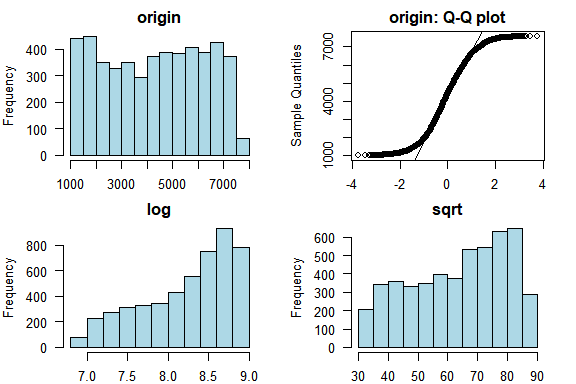

**[ age_years ]**

normality test : Shapiro-Wilk normality test

```
 statistic : 0.97625,  p-value : 4.30622E-28
```

skewness and kurtosis

| type | skewness | kurtosis |
| --- | --- | --- |
| original | -0.4851634 | 2.948342 |
| log transformation | -2.8298993 | 12.601548 |
| sqrt transformation | -1.3671228 | 5.255341 |

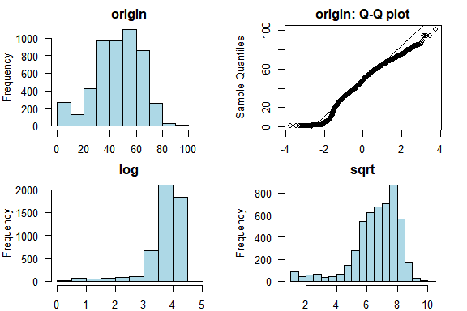

**[ bmi ]**

normality test : Shapiro-Wilk normality test

```
 statistic : 0.04593,  p-value : 9.64591E-95
```

skewness and kurtosis

| type | skewness | kurtosis |
| --- | --- | --- |
| original | 23.32058 | 636.4937 |
| log transformation | NaN | NaN |
| sqrt transformation | 12.08584 | 191.1199 |

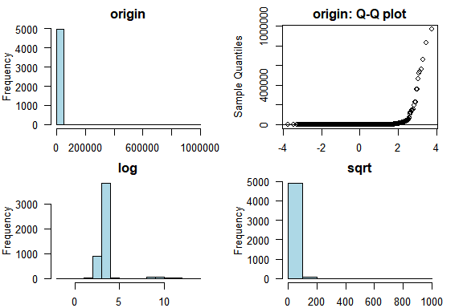

**[ height_cm ]**

normality test : Shapiro-Wilk normality test

```
 statistic : 0.03735,  p-value : 5.936E-95
```

skewness and kurtosis

| type | skewness | kurtosis |
| --- | --- | --- |
| original | 45.966474 | 2224.49803 |
| log transformation | -3.929156 | 21.38664 |
| sqrt transformation | 13.951540 | 465.14264 |

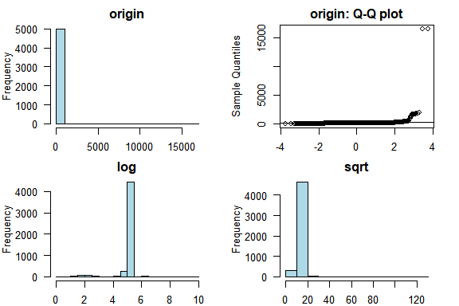

**[ weight_kg ]**

normality test : Shapiro-Wilk normality test

```
 statistic : 0.73431,  p-value : 4.48798E-67
```

skewness and kurtosis

| type | skewness | kurtosis |
| --- | --- | --- |
| original | 4.810332 | 68.93129 |
| log transformation | -2.165122 | 13.11729 |
| sqrt transformation | 0.346315 | 15.20541 |

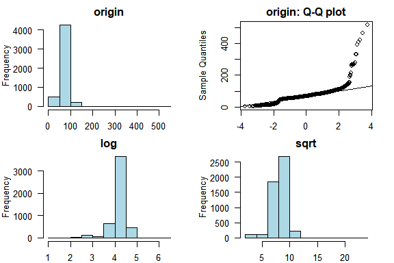

# 3 Relationship Between Variables

## 3.1 Correlation Coefficient

### 3.1.1 Correlation Coefficient by Variable Combination

```
No correlation coefficient is greater than 0.5.
```

### 3.1.2 Correlation Plot of Numerical Variables

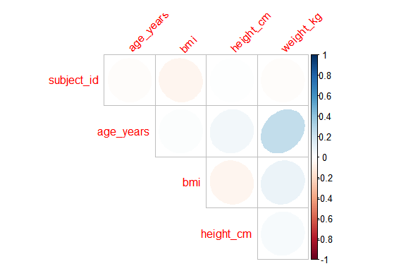

# 4 Target based Analysis

## 4.1 Grouped Descriptive Statistics

### 4.1.1 Grouped Numerical Variables

There is no target variable.

### 4.1.2 Grouped Categorical Variables

There is no target variable.

## 4.2 Grouped Relationship Between Variables

### 4.2.1 Grouped Correlation Coefficient

```
There is no target variable.
```

### 4.2.2 Grouped Correlation Plot of Numerical Variables

```
There is no target variable.
```